# examples_0112

There are 4 basic transformations in Frieze groups:

- Translation
- Rotation (by 180$^\circ$)
- Glide reflection (reflect vertically then translate horizontally)
- Mirror (reflect horizontally)

Label the four visual representations below:

## Transformation 1

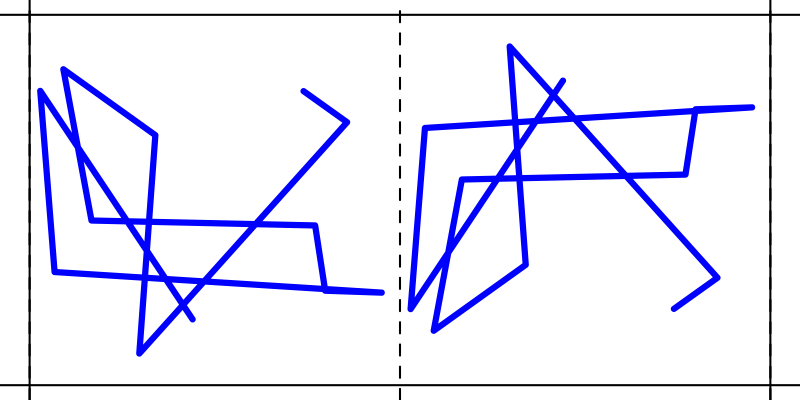

## Transformation 2

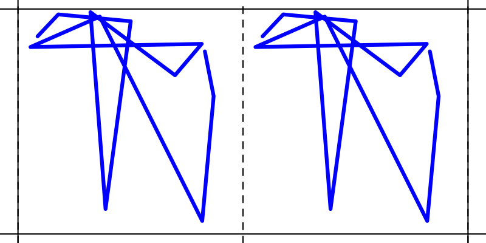

## Transformation 3

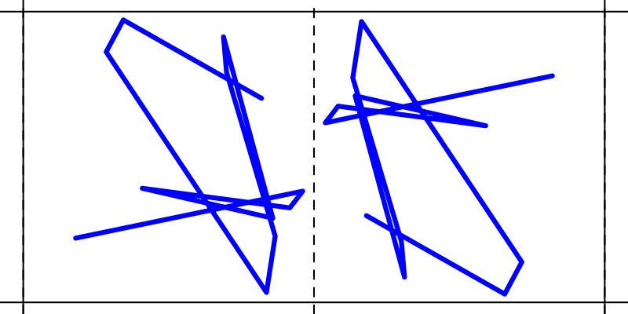

## Transformation 4

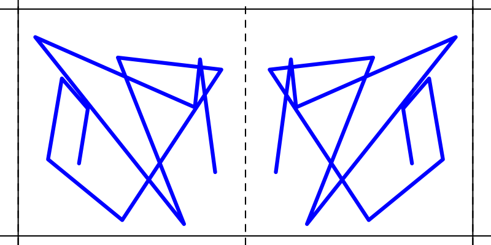

- Transformation 1: glide.
- Transformation 2: translation.
- Transformation 3: rotation.
- Transformation 4: mirror.

3, 1, 2, 4

There are 4 basic transformations in Frieze groups:

- Translation
- Rotation (by 180$^\circ$)
- Glide reflection (reflect vertically then translate horizontally)
- Mirror (reflect horizontally)

Label the four visual representations below:

## Transformation 1

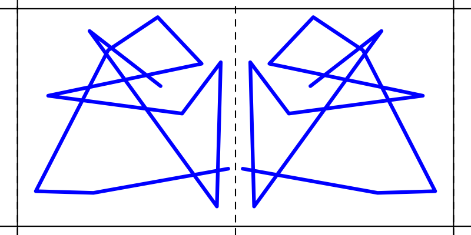

## Transformation 2

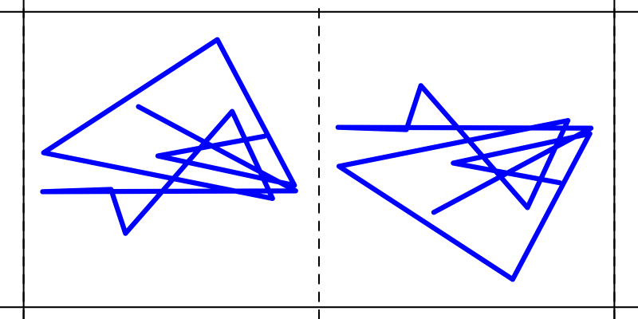

## Transformation 3

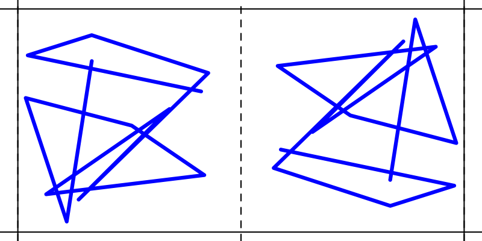

## Transformation 4

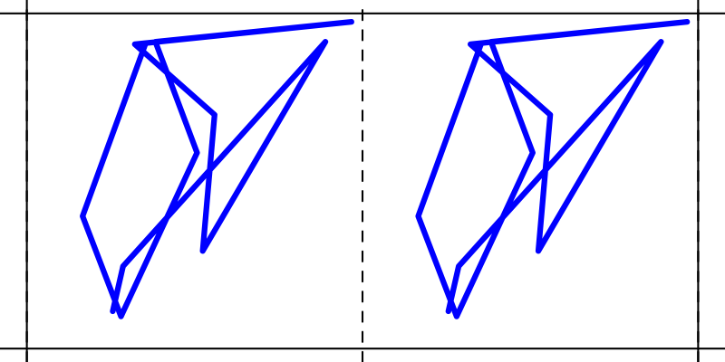

- Transformation 1: mirror.
- Transformation 2: glide.
- Transformation 3: rotation.
- Transformation 4: translation.

4, 3, 2, 1

There are 4 basic transformations in Frieze groups:

- Translation
- Rotation (by 180$^\circ$)
- Glide reflection (reflect vertically then translate horizontally)
- Mirror (reflect horizontally)

Label the four visual representations below:

## Transformation 1

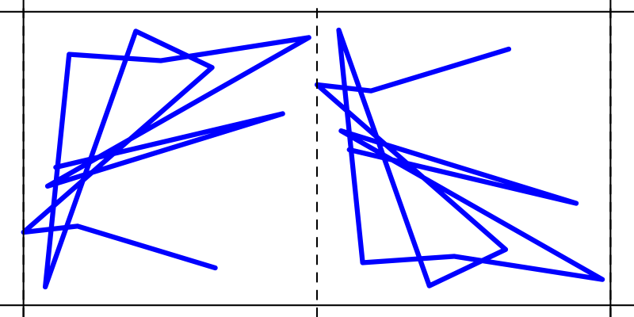

## Transformation 2

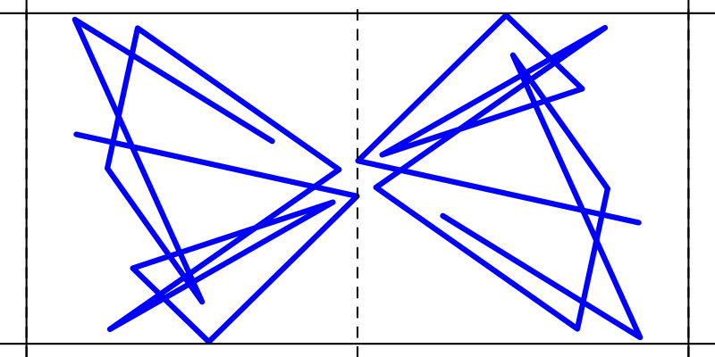

## Transformation 3

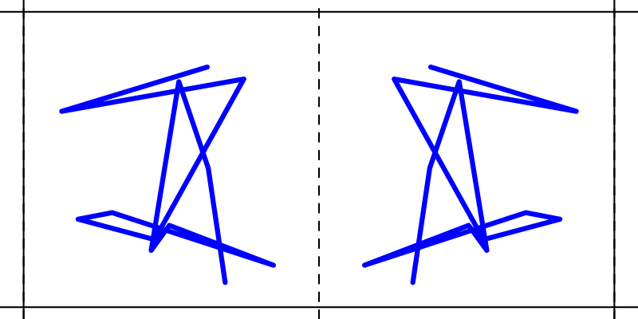

## Transformation 4

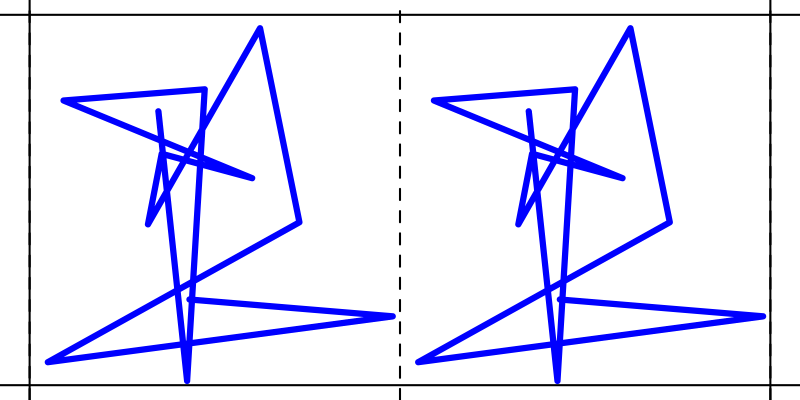

- Transformation 1: glide.
- Transformation 2: rotation.
- Transformation 3: mirror.
- Transformation 4: translation.

3, 2, 4, 1

There are 4 basic transformations in Frieze groups:

- Translation
- Rotation (by 180$^\circ$)
- Glide reflection (reflect vertically then translate horizontally)
- Mirror (reflect horizontally)

Label the four visual representations below:

## Transformation 1

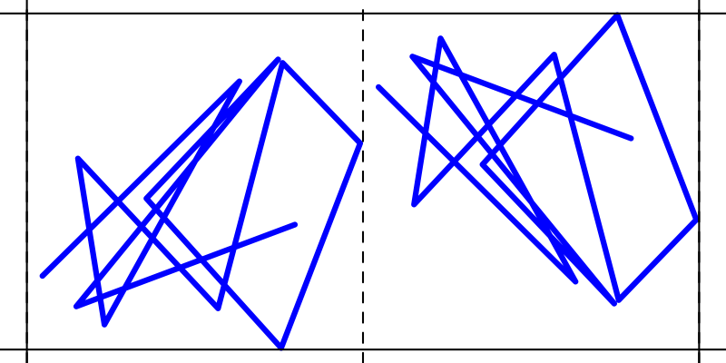

## Transformation 2

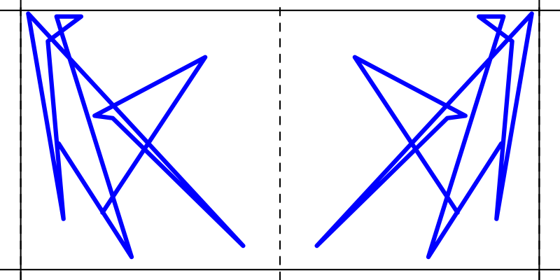

## Transformation 3

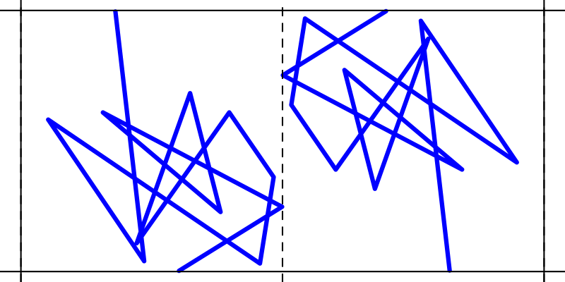

## Transformation 4

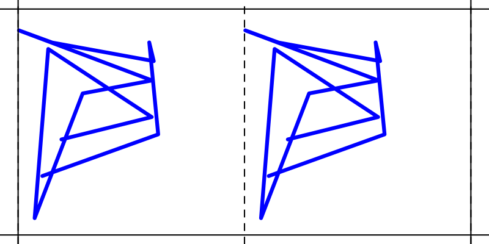

- Transformation 1: glide.
- Transformation 2: mirror.
- Transformation 3: rotation.
- Transformation 4: translation.

3, 4, 2, 1

For each of the patterns below, determine the Frieze group.

## Pattern 1

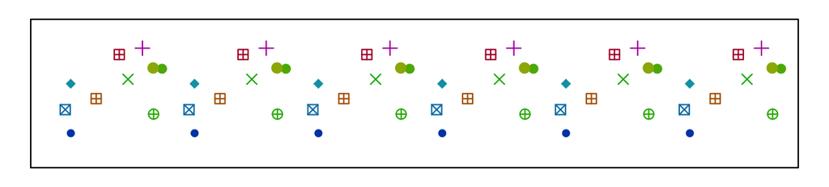

Match the IUC name:

## Pattern 2

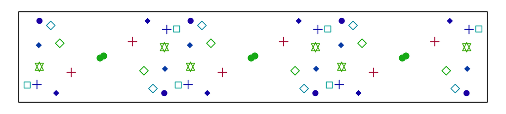

Match the Conway nickname:

- The first pattern is a p1 (which is also called hop).
- The second pattern is a spinning hop (which is also called p2).

For each of the patterns below, determine the Frieze group.

## Pattern 1

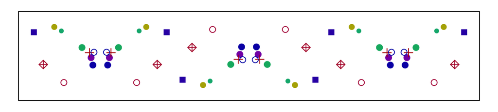

Match the IUC name:

## Pattern 2

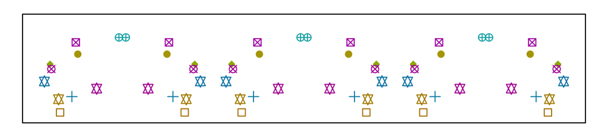

Match the Conway nickname:

- The first pattern is a p2mg (which is also called spinning sidle).
- The second pattern is a sidle (which is also called p1m1).

For each of the patterns below, determine the Frieze group.

## Pattern 1

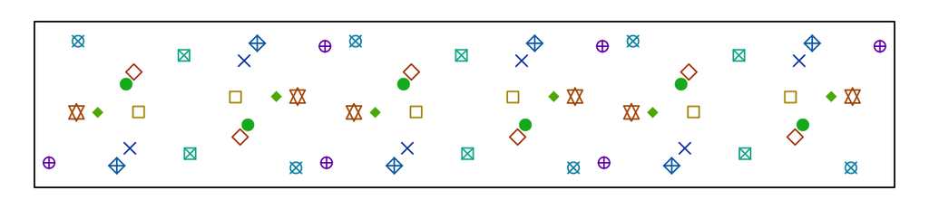

Match the IUC name:

## Pattern 2

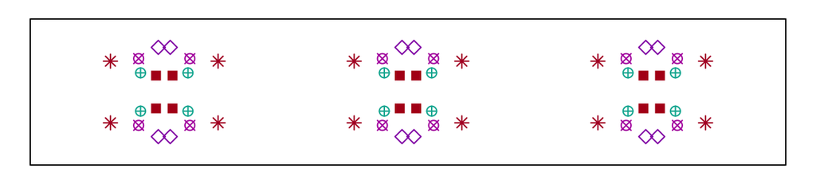

Match the Conway nickname:

- The first pattern is a p2 (which is also called spinning hop).
- The second pattern is a spinning jump (which is also called p2mm).